# Cluster analysis

## Complete Linkage: Step 3 (merge 5 & 6)

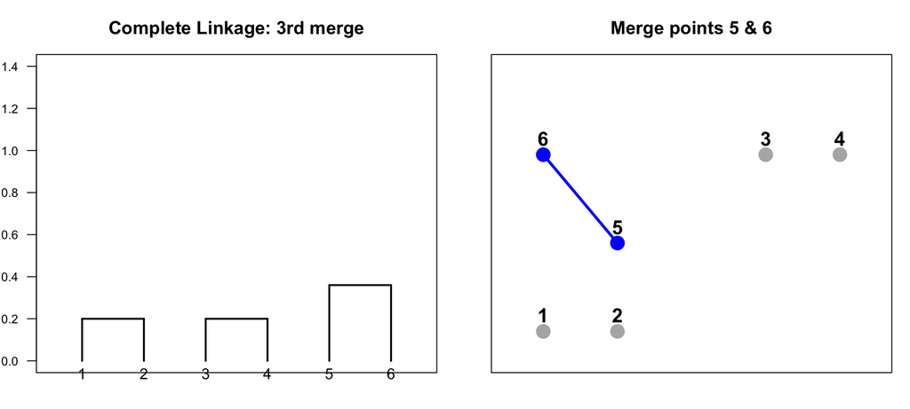

**Points 5 & 6** form a cluster at height ≈ 0.36 → **3 clusters**: {1,2}, {3,4}, {5,6}

## Complete Linkage: Step 4 ({1,2} joins {5,6})

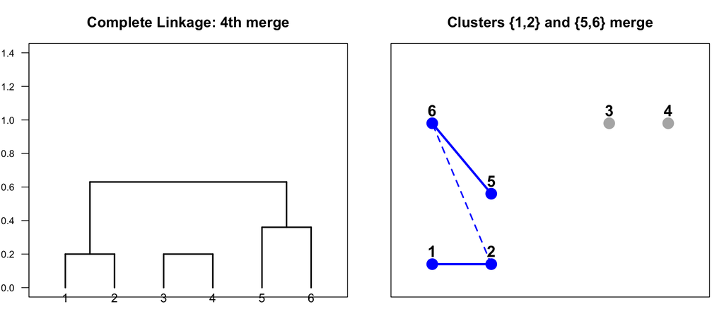

**Clusters {1,2} and {5,6}** merge at height equal to the maximum distance between any point in {1,2} and any point in {5,6}, which in this case is the distance between points 6 and 2 (≈ 0.63) → **2 clusters**: {1,2,5,6}, {3,4}

## Complete Linkage: Step 5 (final merge)

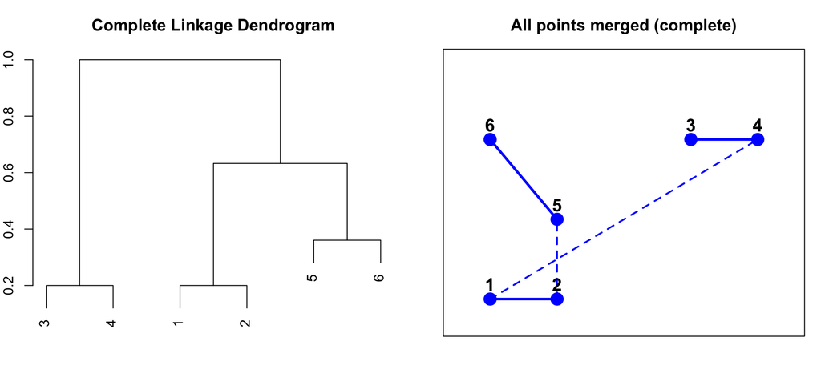

**Final merge**: Clusters {1,2,5,6} and {3,4} join at height ≈ 1.00 → **1 cluster**

## Average Linkage: Step 1 (merge 1 & 2)

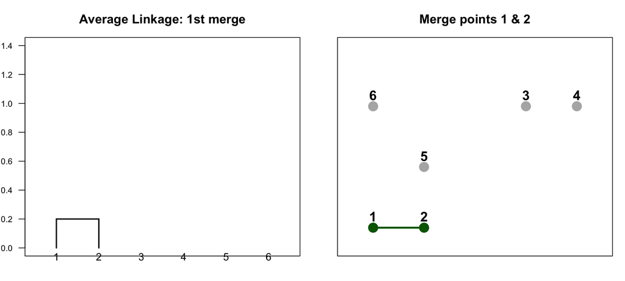

## Average Linkage: Step 2 (merge 3 & 4)

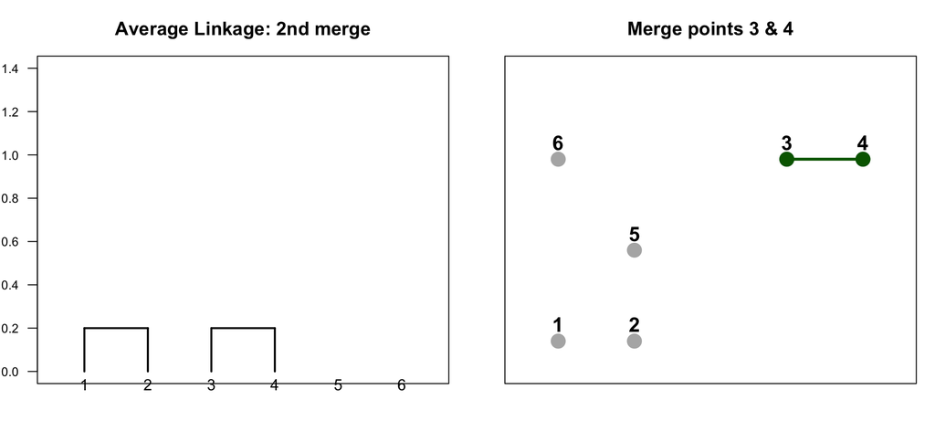

## Average Linkage: Step 3 (5 joins {1,2})

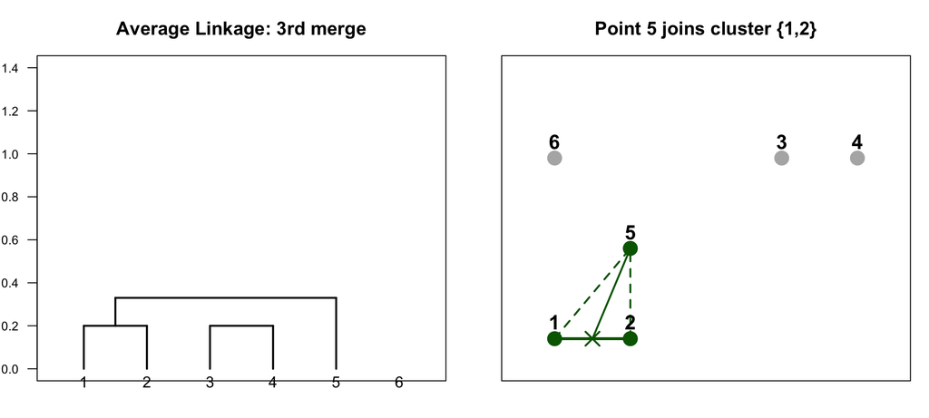

## Average Linkage: Step 4 (6 joins {1,2,5})

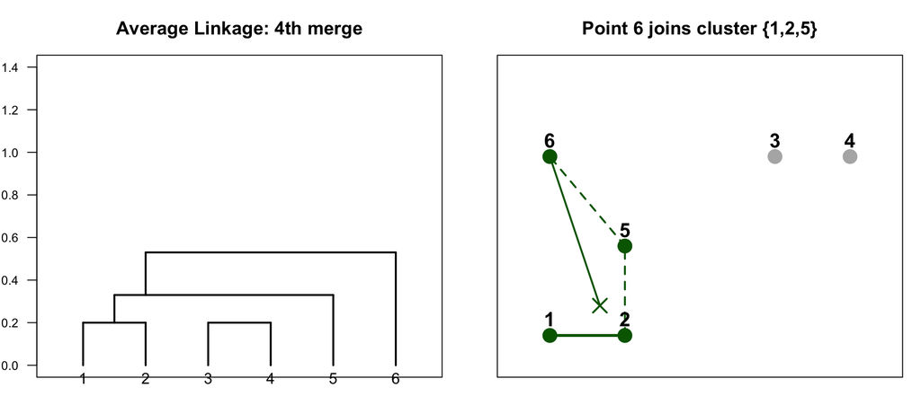

## Average Linkage: Step 5 (final merge)

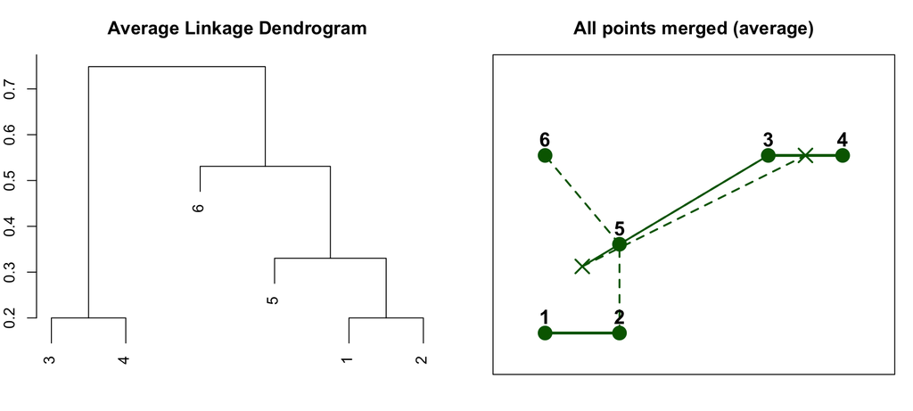

**Final merge**: Clusters {1,2,5,6} and {3,4} join at height ≈ 0.75 → **1 cluster**

## Comparison: Different Linkage, Different Clusters

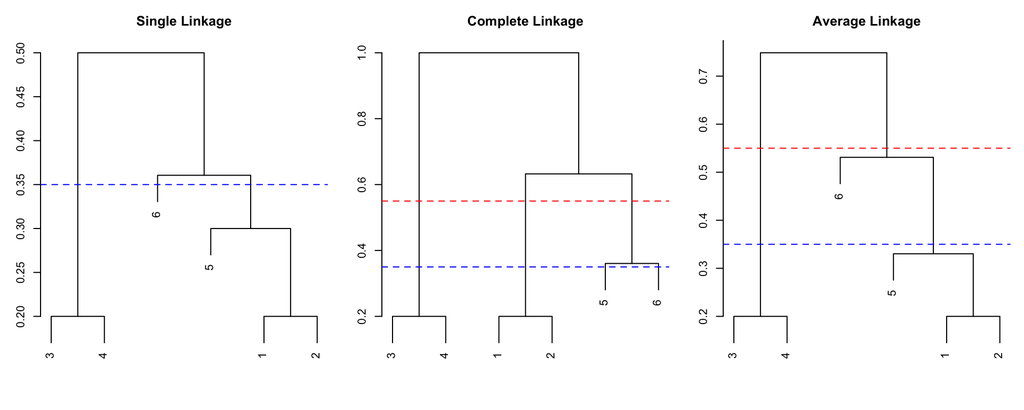

So the same data and same cut height give **different clusterings** for different linkage methods.

## Hierarchical clustering in R

In Rstudio we can use the `hclust()-function` to perform hierarchical clustering.

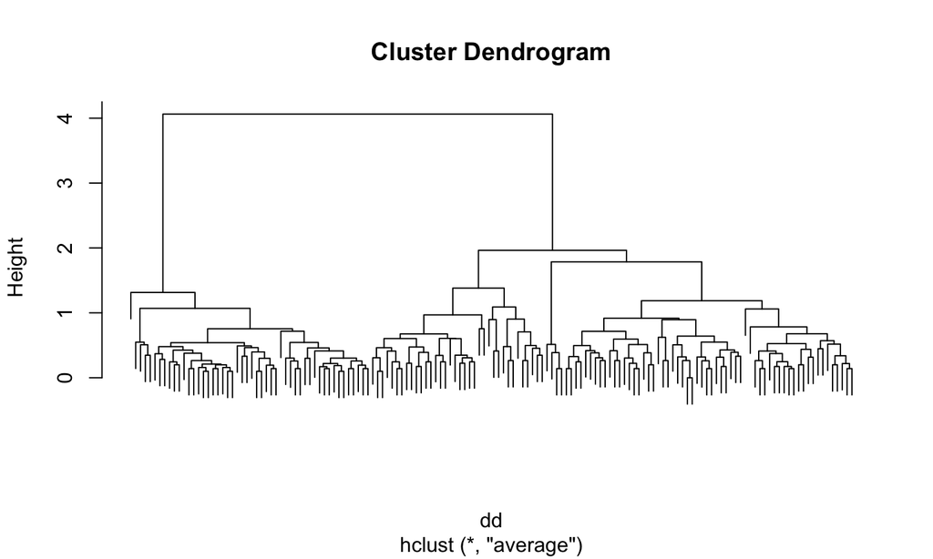

```r
dd <- dist(df_iris, method="euclidean")
hc <- hclust(dd, method="average")
plot(hc, labels = FALSE)
```

A dendrogram is a tree diagram showing the arrangement of the clusters produced by hierarchical clustering.

Let’s try different agglomeration methods and study so-called dendrograms.

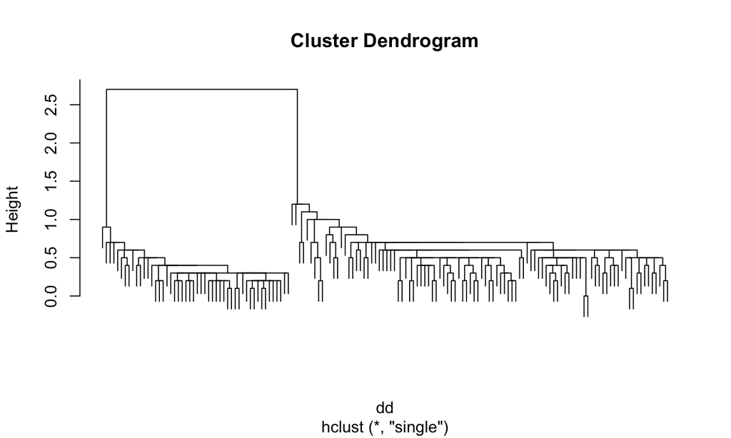

```r
dd <- dist(df_iris, method="manhattan")
hc <- hclust(dd, method="single")
plot(hc, labels = FALSE)
```

## Choosing the number of clusters

With a dendrogram, we **cut** it at some height to obtain \(K\) clusters `cutree(hc, k = 3) or cutree(hc, h = 3.5)`.

**How to choose the cut height or** \(K\)**?**

1. **Visual inspection**: Look for large jumps in height — cut just before a big jump.
2. **Domain knowledge**: If you expect \(K\) groups based on the problem context.
3. **Internal validation**: Use quality metrics (e.g., **silhouette** coefficient, **WCSS**) for different \(K\).
4. **External validation (if labels available)**: Compare at different heights to ground-truth using the **Adjusted Rand Index (ARI)**. Range [−1, 1]; 1 = perfect, 0 = random. Or **F scores** for continuous labels.

## Compare hc and km clusters K = 3

## Compare hc and km clusters K = 3

```r
adjustedRandIndex(cutree(hc, k = 3), iris$Species)
```

```
## [1] 0.7591987
```

```r
adjustedRandIndex(km$cluster, iris$Species)
```

```
## [1] 0.7302383
```

```r
wcss(cutree(hc, k = 3))
```

```
## [1] 3891.643
```

```r
wcss(km$cluster)
```

```
## [1] 3924.729
```

## Elbow plots for WCSS and K

Do not need to recompute! Same dendrogram.

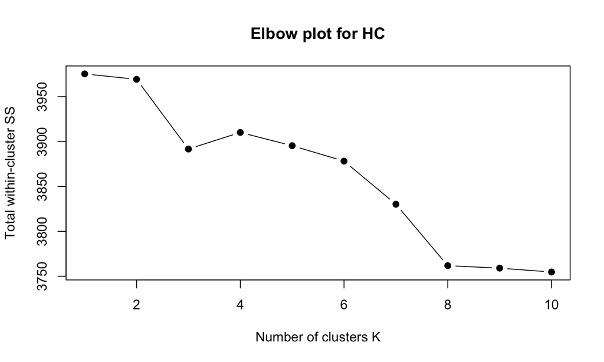

## Elbow plots for WCSS and height

Do not need to recompute! Same dendrogram.

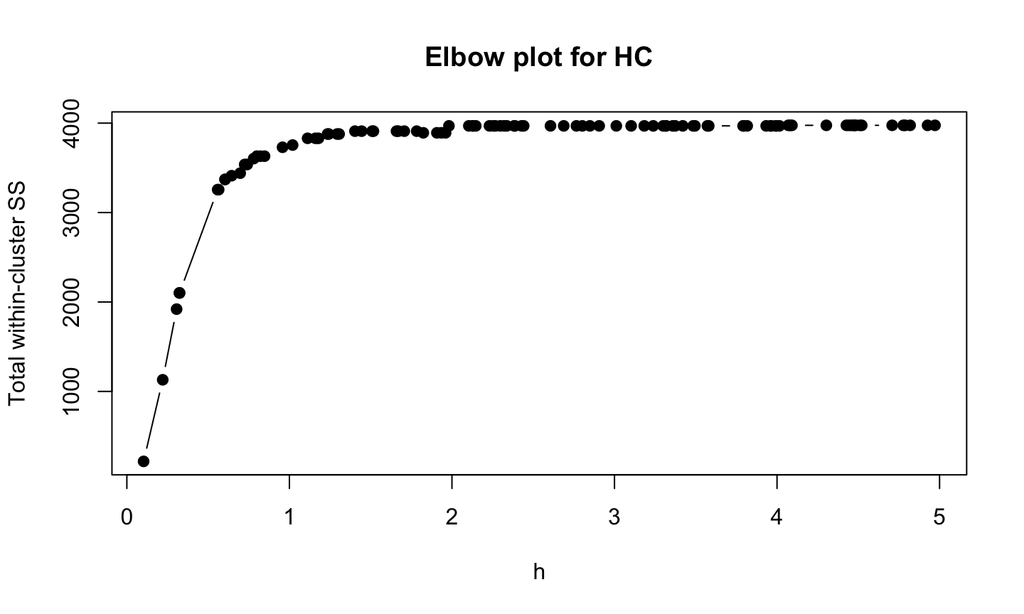

## Elbow plots for ARI and K

Do not need to recompute! Same dendrogram.

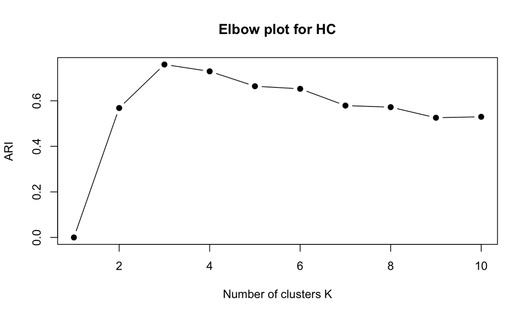

## Elbow plots for ARI and height

Do not need to recompute! Same dendrogram.

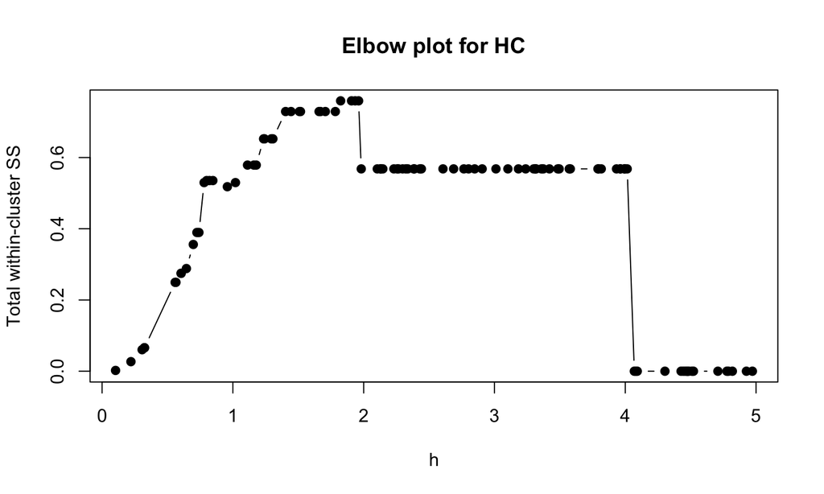

## Elbow plots for ARI and K for K-means

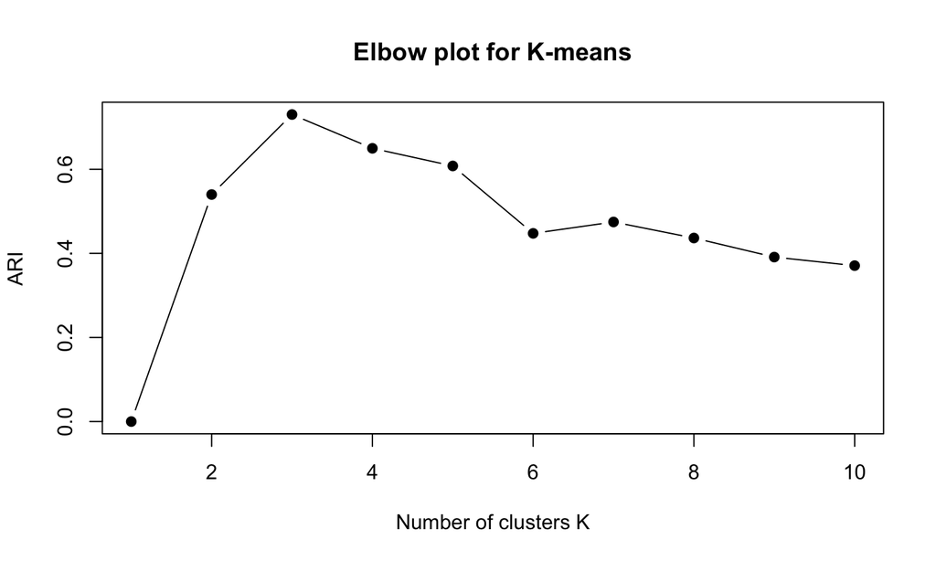

## **Silhouette coefficient**

**Internal validation** (no ground-truth labels):

- **Silhouette coefficient** for observation \(i\): \[ s(i) = \frac{b(i) - a(i)}{\max\{a(i), b(i)\}}, \] where \(a(i)\) = average distance to points in same cluster,  
  \(b(i)\) = average distance to points in nearest other cluster.  
  Range: [−1, 1]. Values near 1 = well-clustered, near 0 = borderline, negative = misclassified.
- **Average silhouette**: mean of \(s(i)\) over all observations (higher is better).

## Evaluating clustering quality with **silhouette**

```r
sil <- silhouette(cutree(hc, k = 3), dist(iris[,1:4]))
mean(sil[, 3]) # Average silhouette width
```

```
## [1] 0.5541609
```

```r
sil <- silhouette(cutree(hc, h = 3), dist(iris[,1:4]))
mean(sil[, 3]) # Average silhouette width
```

```
## [1] 0.6867351
```

```r
sil <- silhouette(km$cluster, dist(iris[,1:4]))
mean(sil[, 3]) # Average silhouette width
```

```
## [1] 0.3223781
```

## Elbow plots for silhouette and K

Do not need to recompute! Same dendrogram.

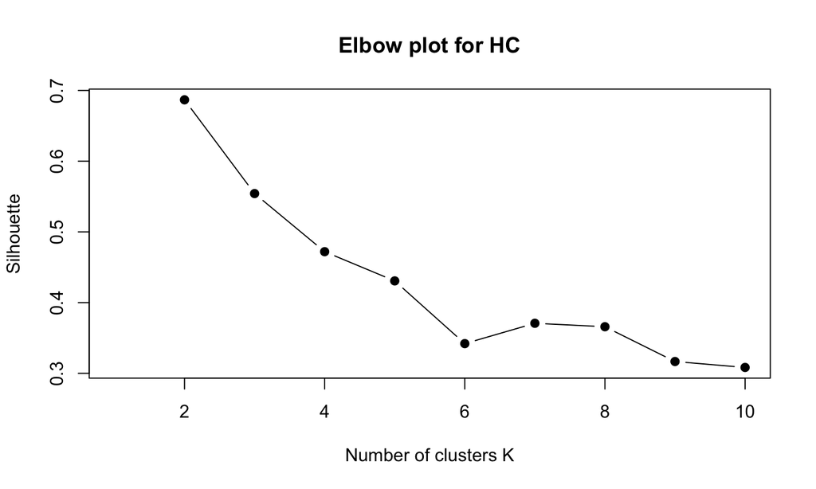

## Elbow plots for silhouette and height

Do not need to recompute! Same dendrogram.

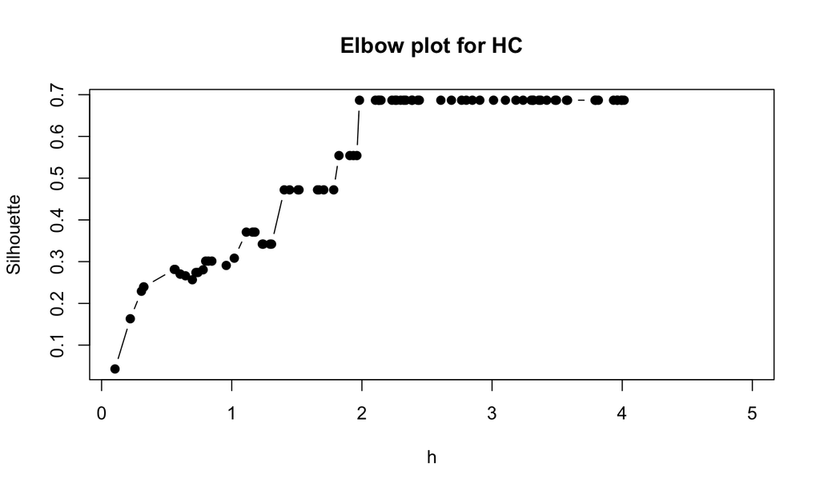

## Other clustering methods not covered

**Model-based clustering:**

- **Mixture models**: Fit mixtures of distributions to data using the EM algorithm; provides soft cluster assignments (probabilities) and statistically principled model selection (BIC).
- R: `Mclust` (package `mclust`).

## Other clustering methods not covered

**Density-based clustering:**

- **DBSCAN** (Density-Based Spatial Clustering of Applications with Noise): Finds clusters of arbitrary shape based on local density; automatically detects noise/outliers; does not require specifying \(K\) in advance.
- R: `dbscan()` (package `dbscan`).

## Other clustering methods not covered

**Graph-based clustering:**

- **Spectral clustering**: Uses eigenvectors of the graph Laplacian to embed data in low-dimensional space, then applies k-means; effective for non-convex clusters.

## Other clustering methods not covered

**Soft clustering:**

- **Fuzzy c-means**: Assigns each observation a membership degree (between 0 and 1) to each cluster instead of hard assignment; useful when boundaries are uncertain.
- R: `cmeans()`

**Others:** Self-organizing maps (Kohonen maps), dynamic time warping for time-series clustering.

## Assignment results

## Overview

**Assignment 1 – STAT340 (2026)**

- Answers: 41
- Questions: 25
- Mean score: 23.66 / 25
- Correct rate: 94.6 %

## Score distribution

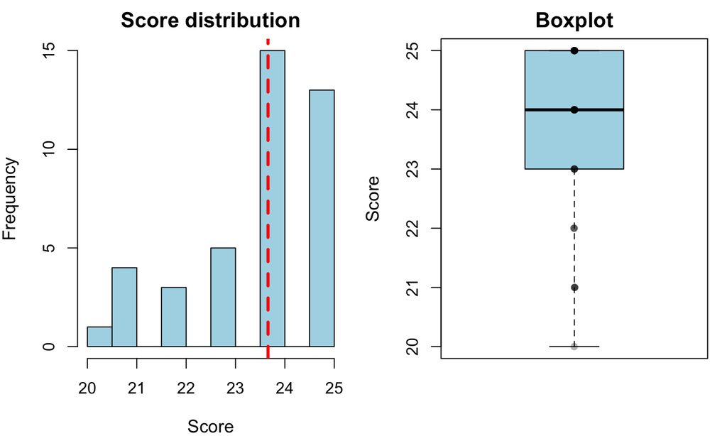

## How to run clustering here?

Which distance?

Which method?

How to select the number of clusters?

## **Clustering setup**

- Data: 25-dimensional binary vectors (correct/incorrect)
- Distance: binary Hamming distance (number of different answers)
- Method: PAM (Partitioning Around Medoids) on the distance matrix
- Number of clusters: chosen by an F-type criterion
  - For each k = 2, …, 8:
    - run PAM,
    - compute F-ratio = between-cluster variance / within-cluster variance (of the scores),
    - require at least 3 answers per cluster.
  - Choose k with the largest F-ratio.

## PAM clustering

**Optimal number of clusters (PAM):** 2

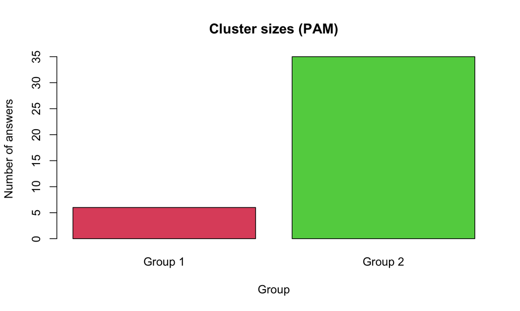

## Cluster statistics

| Group | N | Mean | SD | Min | Max |
| --- | --- | --- | --- | --- | --- |
| Group 1 | 6 | 22.67 | 1.37 | 21 | 24 |
| Group 2 | 35 | 23.83 | 1.34 | 20 | 25 |

## Score distributions by group

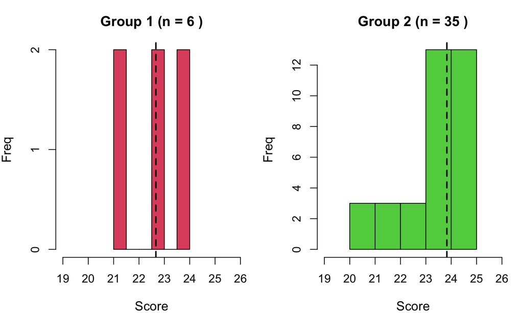

## Boxplot by group

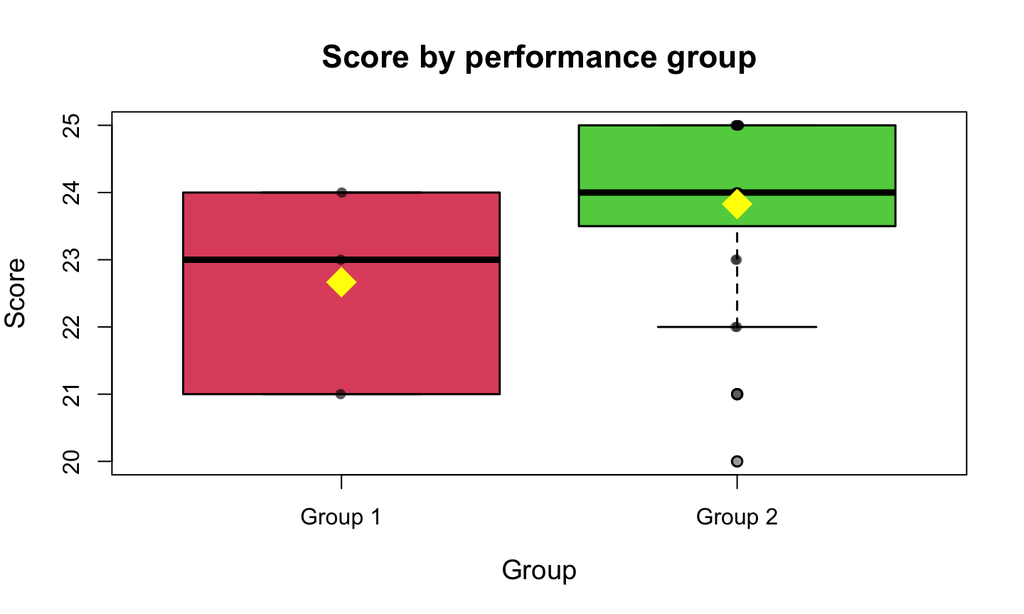

## Answer pattern heatmap

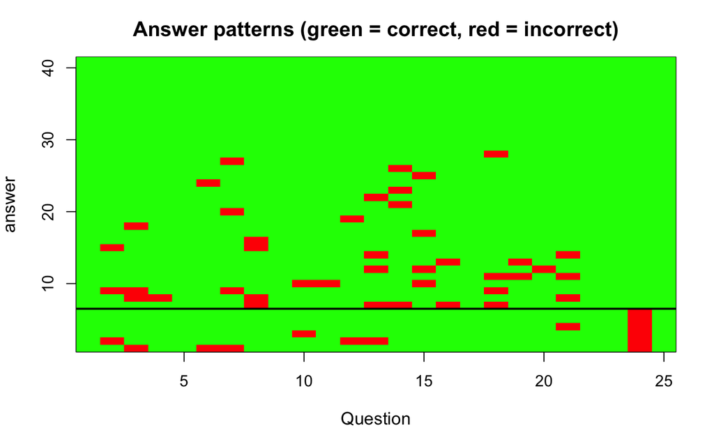

## ANOVA results

**One-way ANOVA: score ~ performance group**

```
##             Df Sum Sq Mean Sq F value Pr(>F)
## performance  1   6.91   6.915   3.836 0.0573 .
## Residuals   39  70.30   1.803
## ---
## Signif. codes:  0 '***' 0.001 '**' 0.01 '*' 0.05 '.' 0.1 ' ' 1
```

**Result:** F = 3.84, p = 0.057

## Post-hoc: Tukey HSD

```
##   Tukey multiple comparisons of means
##     95% family-wise confidence level
##
## Fit: aov(formula = score ~ performance, data = results_df)
##
## $performance
##                     diff         lwr      upr     p adj
## Group 2-Group 1 1.161905 -0.03806934 2.361879 0.0573483
```

## Summary

- Binary Hamming distance on 25-question 0/1 answer patterns.
- PAM clustering on the Hamming distance matrix.
- Number of clusters chosen by an F-type criterion with minimum cluster size 3.
- ANOVA and Tukey HSD show how groups differ in total score.
- What have we done wrong?

## Assumptions

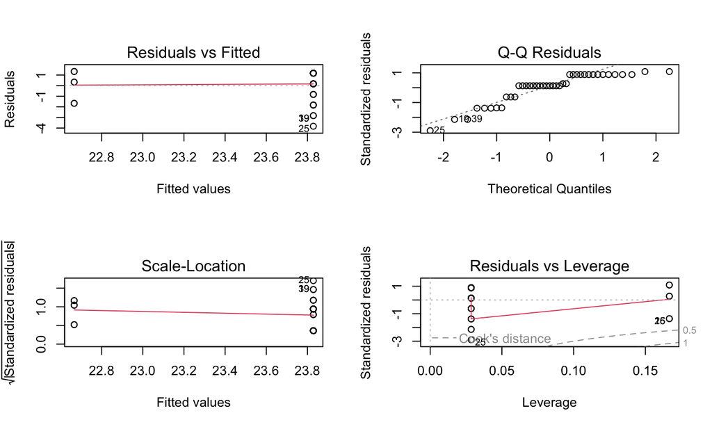